# Plotting Call Presence and Density

As of version 1.11.1, the `PAMmisc` package has two new functions to plot summaries of your detection data, `plotPresBar` and `plotPresGrid`. The only requirement for these functions is a dataframe with a `UTC` column, so they can easily be used with `AcousticStudy` objects from `PAMpal`. It is best if `UTC` is already converted to POSIXct format, but if it is a character you must provide the date format with the `format` argument according to the details in `?strptime`.

## Basic Functionality - plotPresBar

First we’ll pull out the click detection data from our `AcousticStudy`. This already has a `UTC` column, so it can immediately be used for the plotting functions. The `plotPresBar` function can be used to create a bar graph of calls across time. The `bin` argument controls the time bins for plotting. Let’s create a plot that shows how many hours of each day have detections by setting `bin='hours/day'`.

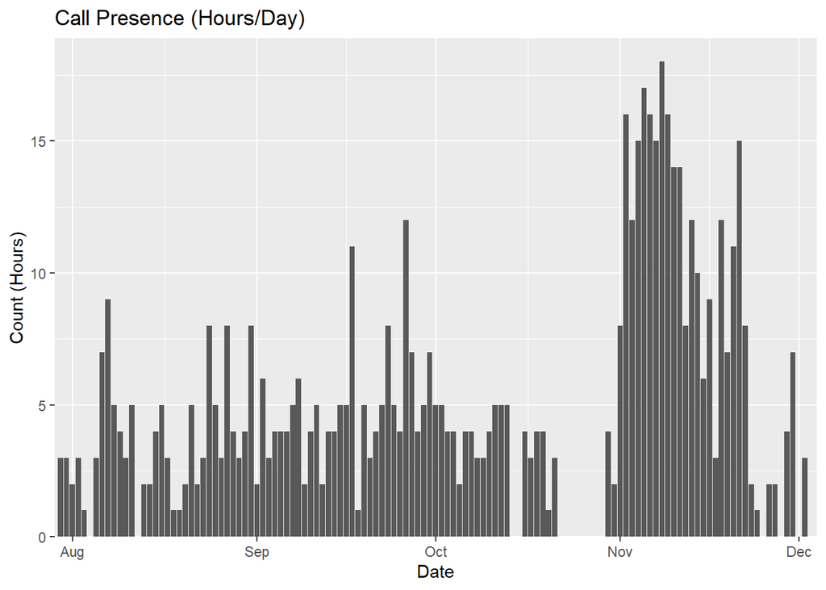

```r
library(PAMpal)
clicks <- getClickData(data)
library(PAMmisc)
plotPresBar(clicks, bin='hours/day')
```

We can also show the number of calls per day by changing bin to just `bin='day'` to show the density of calls rather than just the presence of calls. This can also be specified as `bin='calls/day'`

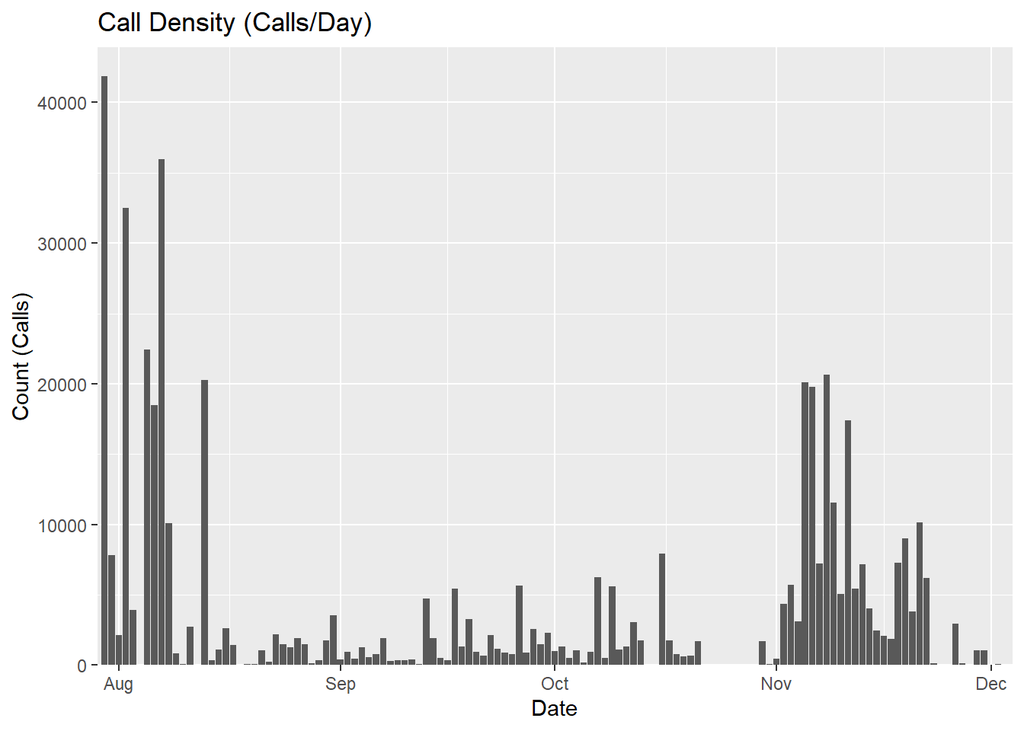

```r
plotPresBar(clicks, bin='day')
```

```r
# plotPresBar(clicks, bin='calls/day') # this is the same
```

`bin` can accept time units of `minute`, `hour`, `day`, `week`, and `month`. Plural forms of these are also accepted. The output is a `ggplot` object, so we can also use the `patchwork` package to organize the plot outputs.

**NOTE** If the time scale of the bins is too small relative to the overall timescale of your data, it is likely that the plot will be incorrect. The `minutes/hour` plot below is probably missing a lot of bars since there are more hours than can be reasonably shown across the 4 months of our entire dataset.

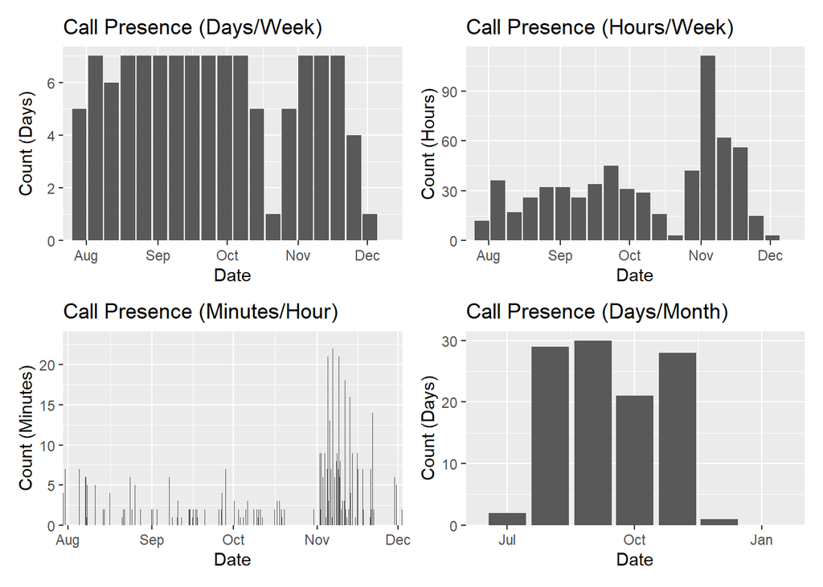

```r
library(patchwork)
# Using patchwork to organize the plots
(plotPresBar(clicks, bin='days/week') +
    plotPresBar(clicks, bin='hour/week')) /
    (plotPresBar(clicks, bin='minutes/hour') +
         plotPresBar(clicks, bin='days/month'))
```

We can also color the bars by another variable in the dataset using the `by` argument to specify the column to color by. Here we show the presence of calls of different species by setting `by='species'`.

**NOTE** This stacks the bars for each species, so it is possible for the total height of the bar to be greater than 24 hours for a given day.

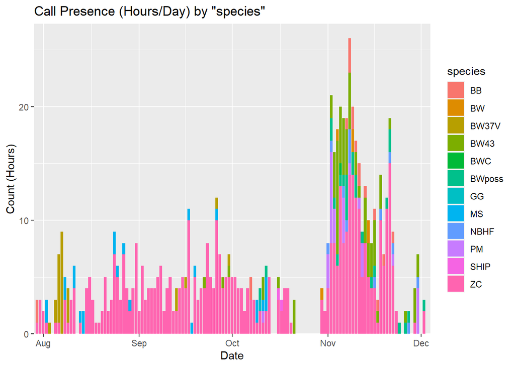

```r
plotPresBar(clicks, bin='hour/day', by='species')
```

## Basic Functionality - plotPresGrid

The `plotPresGrid` function can be useful to visualize the distribution of detections across the course of a day. Additionally, if GPS data is present in the dataframe (or provided separately), it can display dawn/dusk to investigate diurnal patterns.

The data we’ve been working with so far cover a range of deployments along the coast of California, so we’ll filter these down to a single deployment so that the GPS data is for a single location.

```r
clicks$Drift <- gsub('.*(Drift-[0-9]{1,2}).*', '\\1', basename(clicks$db))
drift4 <- clicks[clicks$Drift == 'Drift-4', ]
```

The data we are working with already has GPS data from earlier in the analysis (added with `addGps` prior to this tutorial). The gray shaded background marks the times from dusk to dawn, note that times are always in UTC. With `type='presence'`, the blue boxes represent hours that have detections.

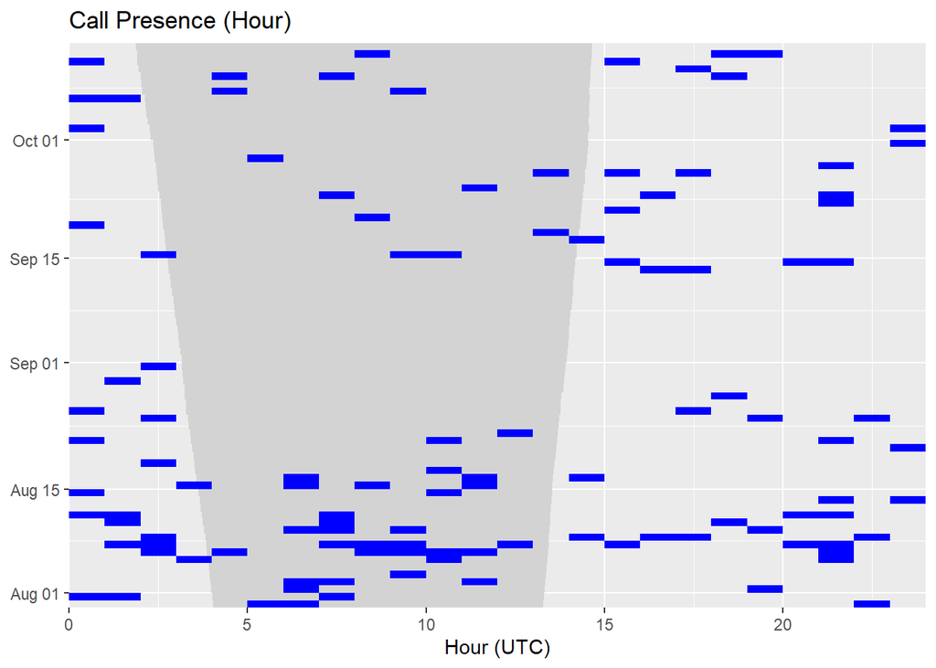

```r
plotPresGrid(drift4, bin = 'hour', type='presence')
```

With `type='density'` we can see the number of detections in each hour.

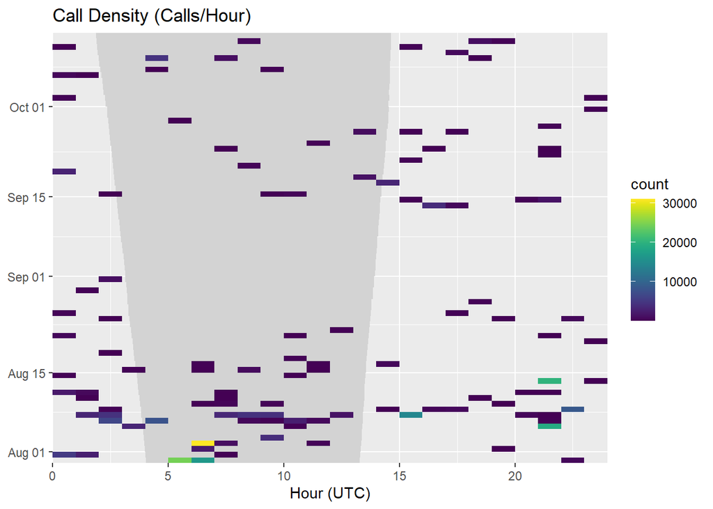

```r
plotPresGrid(drift4, bin='hour', type='density')
```

For `plotPresGrid`, the `bin` argument can be one of `hour`, `30min`, `15min`, or `min`.

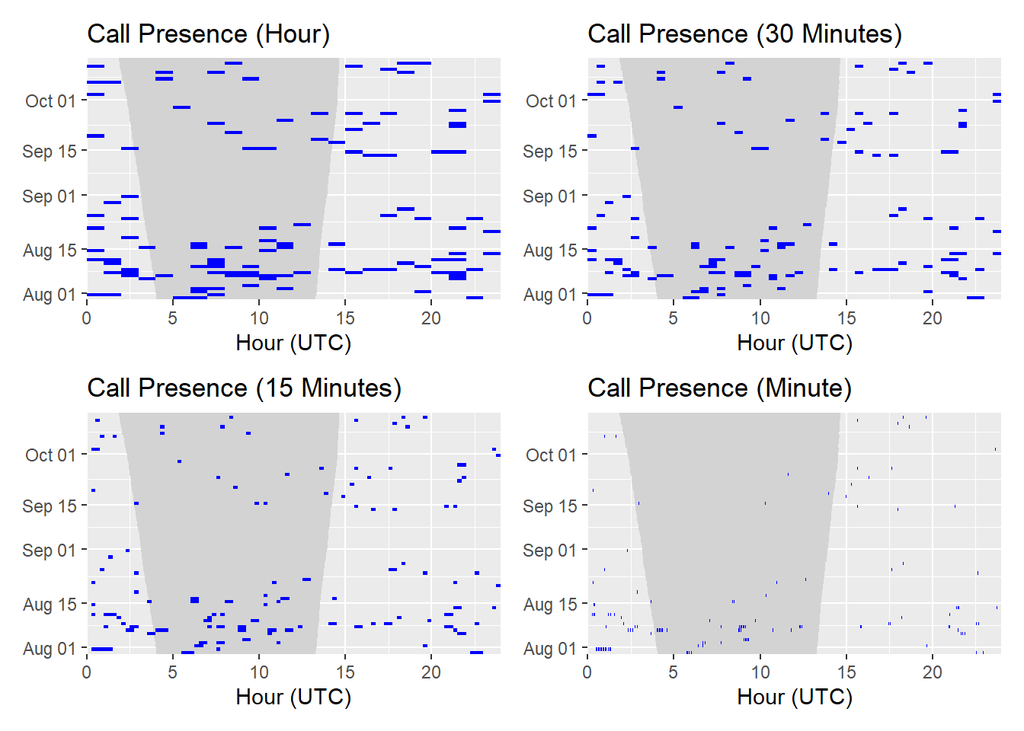

```r
(plotPresGrid(drift4, bin='hour', type='presence') +
     plotPresGrid(drift4, bin='30min', type='presence')) /
    (plotPresGrid(drift4, bin='15min', type='presence') +
         plotPresGrid(drift4, bin='min', type='presence'))
```

Similar to `plotPresBar`, we can also use the `by` argument to create a plot that contains some kind of label information. For `type='presence'` this will create boxes of different colors for each label, with a level of transparency controlled by the `alpha` parameter so that times with multiple labels present can be seen. If there is a lot of overlap, this can create a messy plot that is hard to read. In this case the plot can be split into multiple panels using `ggplot2`’s `facet_wrap`.

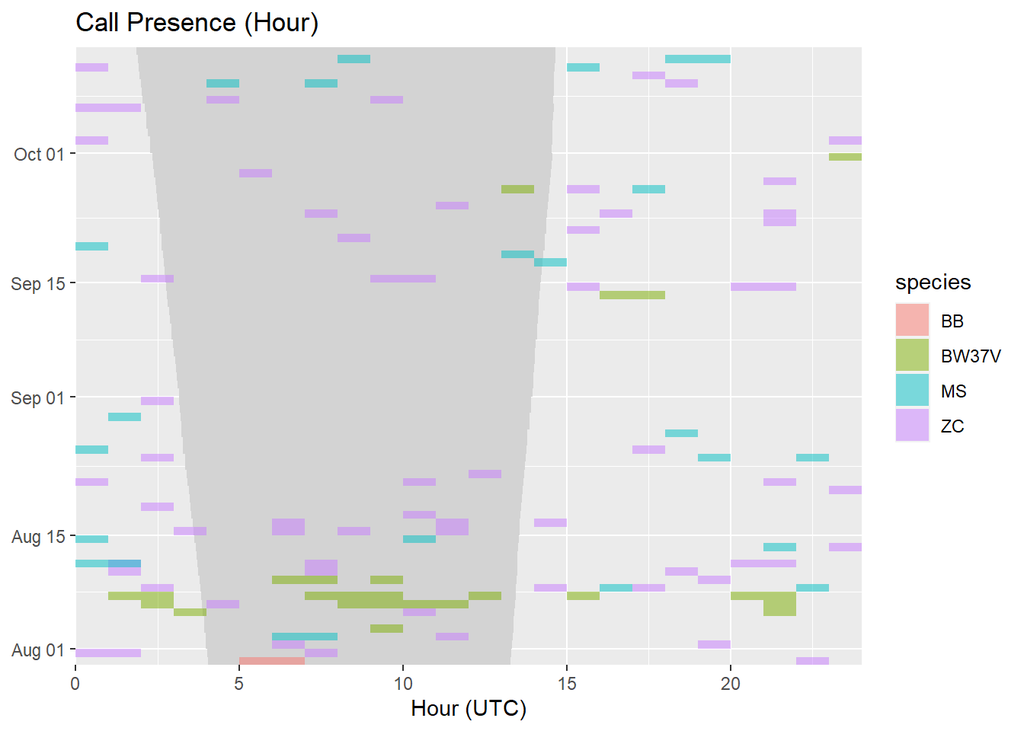

```r
plotPresGrid(drift4, bin='hour', type='presence', by='species')
```

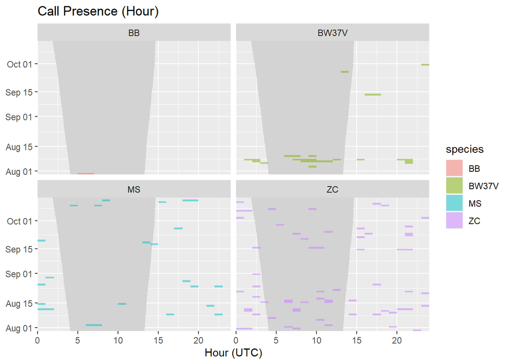

```r
library(ggplot2)
plotPresGrid(drift4, bin='hour', type='presence', by='species') +
    facet_wrap(vars(species))
```

For `type='density'` using the `by` argument will create a multi-panel plot with `facet_wrap` since the color is already being used to show the number of calls. You can change the arrangement of the plot by using `facet_wrap` again and changing the parameters.

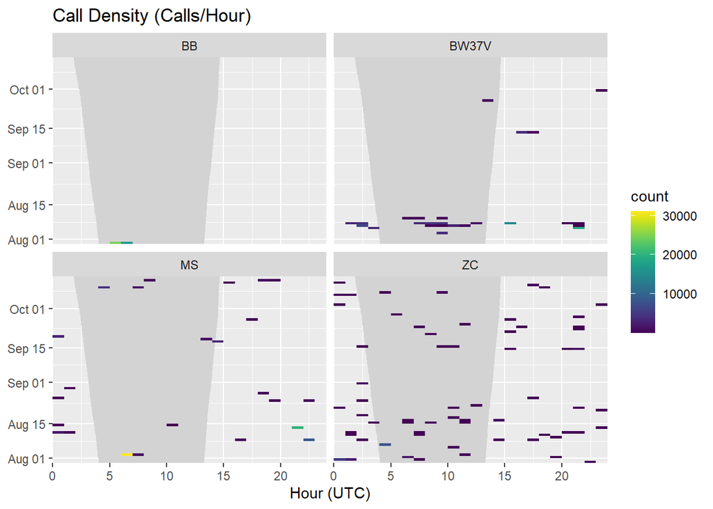

```r
plotPresGrid(drift4, type='density', by='species')
```

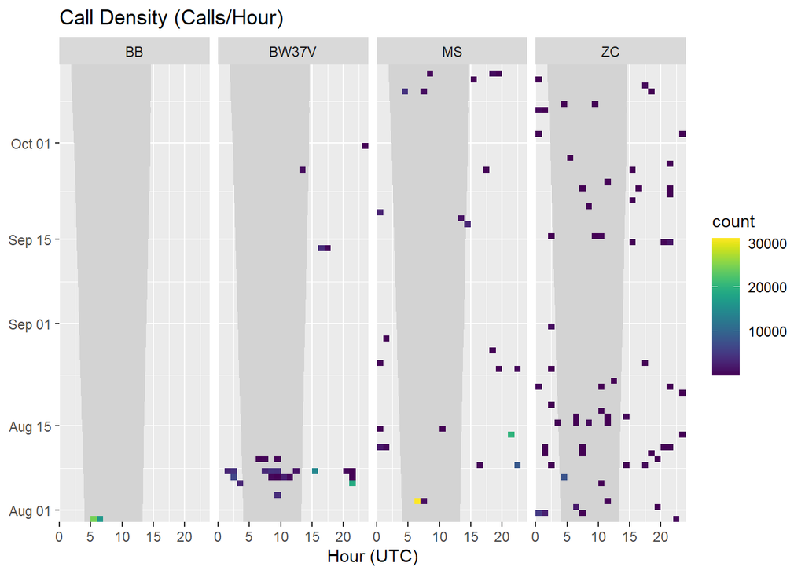

```r
plotPresGrid(drift4, type='density', by='species') +
    facet_wrap(vars(species), nrow=1)
```

## More Options - Both Functions

Both plotting functions can change the default color of the bars/boxes with the `fill` argument.

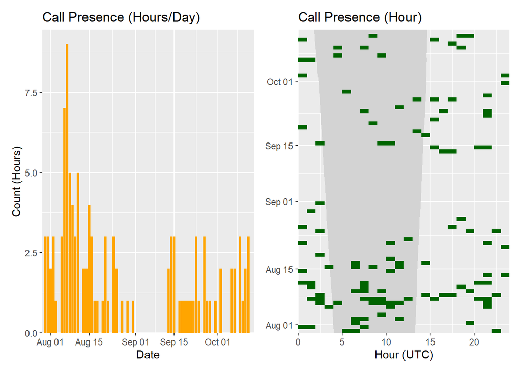

```r
plotPresBar(drift4, bin='hour/day', fill='orange') +
    plotPresGrid(drift4, bin='hour', fill='darkgreen')
```

Both plotting functions can add custom titles to the plot with the `title` argument.

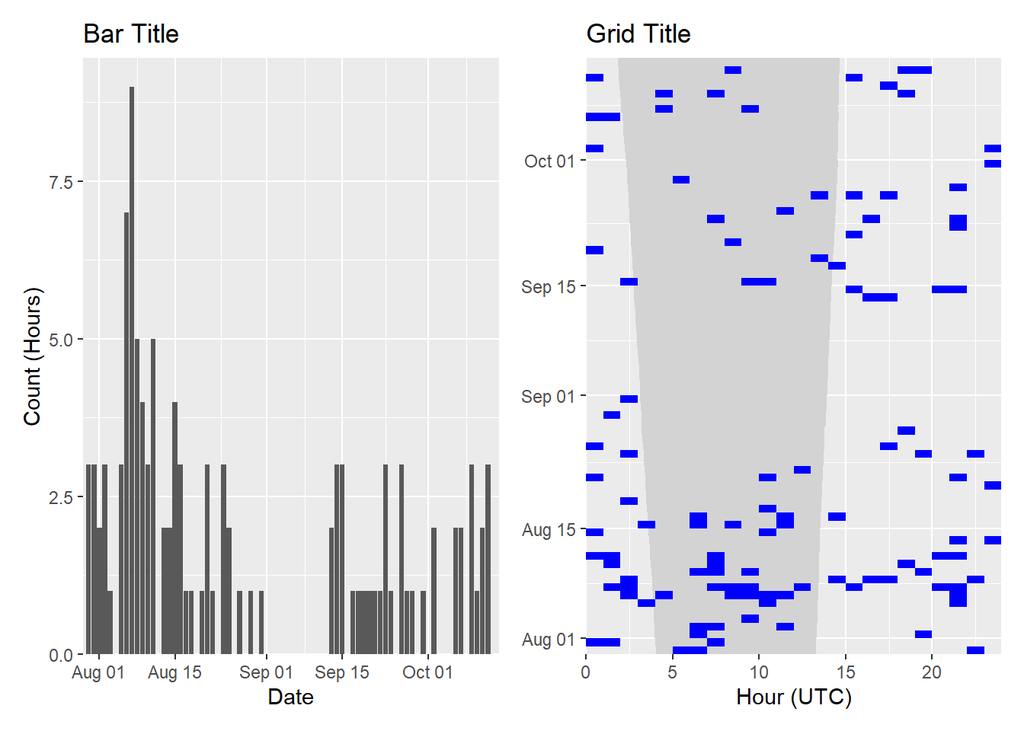

```r
plotPresBar(drift4, bin='hour/day', title='Bar Title') +
    plotPresGrid(drift4, bin='hour', title='Grid Title')
```

Both plotting functions can change the start and end times of the plots with the `start` and `end` arguments (default is min/max time in the dataset).

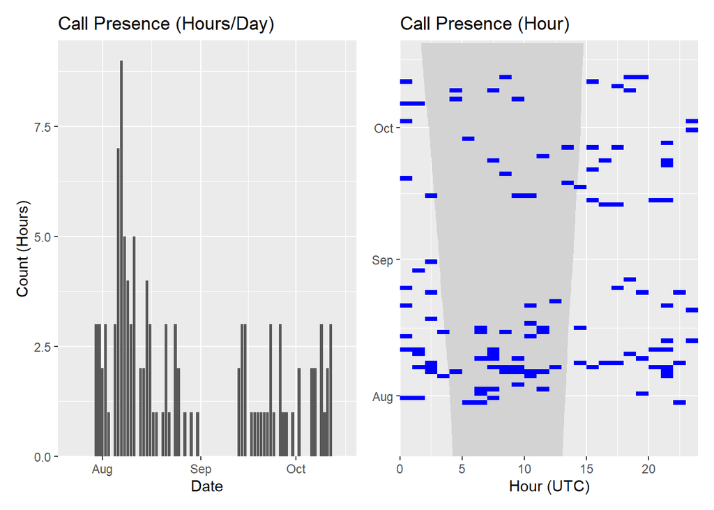

```r
newStart <- min(drift4$UTC) - 12 * 24 * 3600
newEnd <- max(drift4$UTC) + 7 * 24 * 3600
plotPresBar(drift4, bin='hour/day', start=newStart, end=newEnd) +
    plotPresGrid(drift4, bin='hour', start=newStart, end=newEnd)
```

## More Options - plotPresGrid

The dawn/dusk shading only works if GPS data are provided. In our earlier example, columns `Longitude` and `Latitude` are already part of the dataframe, so we did not need to do anything else. You can also provide GPS coordinates directly using the `gps` argument if they are not already attached to your data. This should be a dataframe with columns `UTC`, `Longitude`, and `Latitude`. Here we’ll provide coordinates from a different part of the world to show the difference.

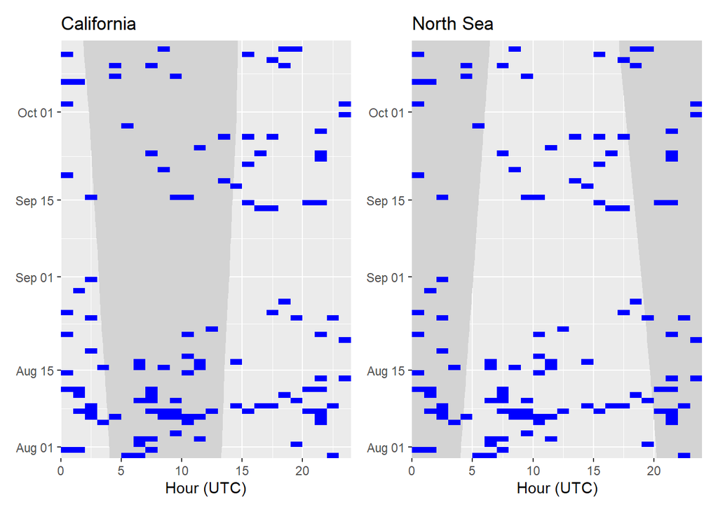

```r
newGps <- data.frame(UTC = min(drift4$UTC), Longitude=0, Latitude=56)
plotPresGrid(drift4, bin='hour', title='California') +
    plotPresGrid(drift4, bin='hour', gps=newGps, title='North Sea')
```

The timezone of the plot axis can also be changed. UTC is required as a standardized input column, but the `plotTz` argument can be used to create a more easily interpreted display. The accepted timezone arguments must come from the `OlsonNames()` function, notable choices that are **NOT** valid include `'PDT'` and `'PST'`.

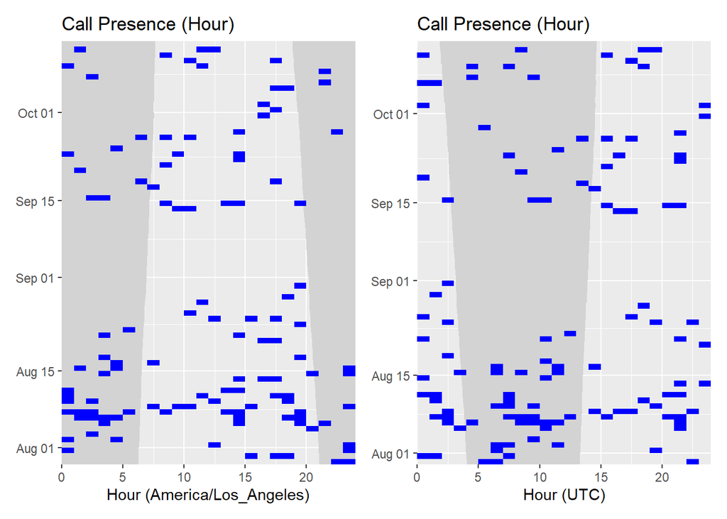

```r
# PDT/PST are not accepted, use America/Los_Angeles instead
plotPresGrid(drift4, plotTz='America/Los_Angeles') +
    plotPresGrid(drift4, plotTz='UTC')
```

In addition to changing the color of the box when plotting presence, we can also change the box outline color with the `color` argument, and we can change the colormap used to plot call density with the `cmap` argument.

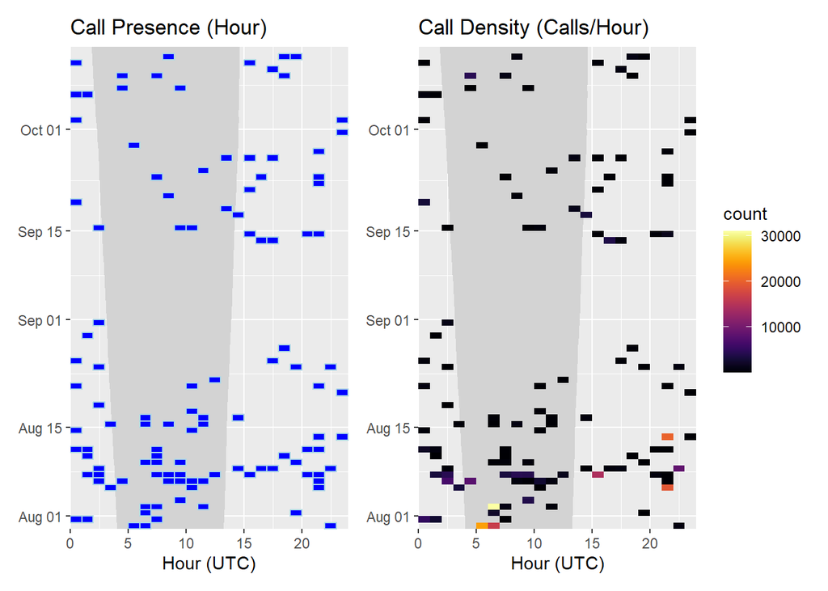

```r
plotPresGrid(drift4, bin='hour', type='presence', color='lightblue', fill='blue') +
    plotPresGrid(drift4, bin='hour', type='density', cmap=viridis::inferno(25))
```